# Question 2

Can we describe the relationship between the amount of seed funding and the year of first funding received?

Jonathan Kerr

18/02/2021

*Our question is based on exploring if the amounts of investments going into start-up companies over the years have steadily increased or not. We will explore if the relationship between the amount of seed funding and the year of obtaining those funds is linear or some other form of relationship.*

Let’s take a quick look at the “first_funding_at” data.

```r
# EDA
eda <- kaggle_data_cleaned %>%
  dplyr::select(first_funding_at) %>%
  dplyr::arrange(first_funding_at)
head(eda)
```

```
##   first_funding_at
## 1       0011-11-14
## 2       1984-01-01
## 3       1987-01-01
## 4       1990-01-01
## 5       1990-01-17
## 6       1990-11-30
```

Let’s bucket the ‘first_funding_at’ by year and filter bad data (funding year 0011) and also use the data that we have adjusted for inflation.

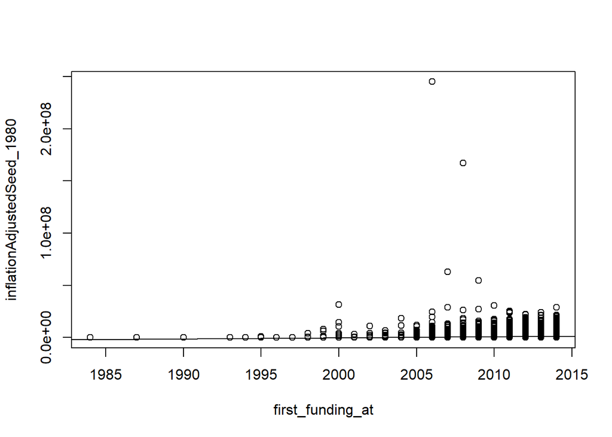

```r
first_year <- 1980
first_funding_date <- kaggle_data_cleaned %>%
  mutate(first_funding_at = as.numeric(substring(first_funding_at, 1,4)) ) %>%
  filter(first_funding_at >= first_year) %>%
  filter(first_funding_at <= 2014)# %>%

model <- lm(formula = inflationAdjustedSeed_1980 ~ first_funding_at, data = first_funding_date)
plot(inflationAdjustedSeed_1980 ~ first_funding_at, data=first_funding_date); abline(model)
```

```r
summary(model)
```

```
##
## Call:
## lm(formula = inflationAdjustedSeed_1980 ~ first_funding_at, data = first_funding_date)
##
## Residuals:
##       Min        1Q    Median        3Q       Max
##  -1243077  -1013477   -723430   -307713 244588357
##
## Coefficients:
##                    Estimate Std. Error t value Pr(>|t|)
## (Intercept)      -208070491   15624355  -13.32   <2e-16 ***
## first_funding_at     103929       7772   13.37   <2e-16 ***
## ---
## Signif. codes:  0 '***' 0.001 '**' 0.01 '*' 0.05 '.' 0.1 ' ' 1
##
## Residual standard error: 3108000 on 18923 degrees of freedom
## Multiple R-squared:  0.009362,   Adjusted R-squared:  0.009309
## F-statistic: 178.8 on 1 and 18923 DF,  p-value: < 2.2e-16
```

This looks like it could be skewed up by the larger number of rounds in later years. So we can try comparing means instead.

```r
mean_compare <- first_funding_date %>%
    group_by(first_funding_at) %>%
    dplyr::summarize(seed_mean = mean(inflationAdjustedSeed_1980, na.rm=TRUE))
```

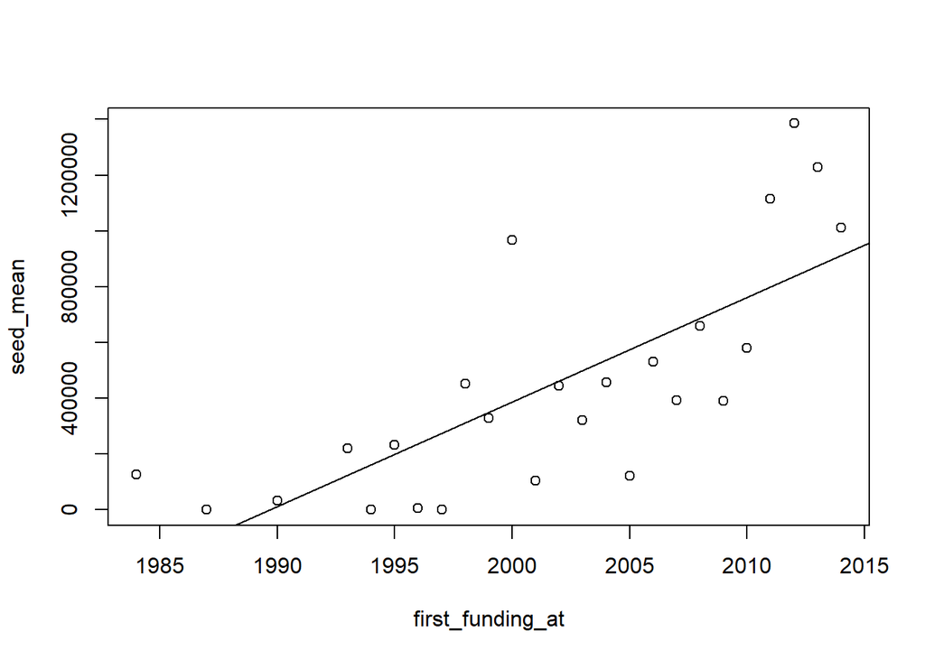

```r
model <- lm(formula = seed_mean ~ first_funding_at, data = mean_compare)
plot(seed_mean ~ first_funding_at, data=mean_compare); abline(model)
```

```r
summary(model)
```

```
##
## Call:
## lm(formula = seed_mean ~ first_funding_at, data = mean_compare)
##
## Residuals:
##     Min      1Q  Median      3Q     Max
## -452119 -182902  -22392  100058  579857
##
## Coefficients:
##                   Estimate Std. Error t value Pr(>|t|)
## (Intercept)      -74563823   13698519  -5.443 1.56e-05 ***
## first_funding_at     37476       6844   5.476 1.44e-05 ***
## ---
## Signif. codes:  0 '***' 0.001 '**' 0.01 '*' 0.05 '.' 0.1 ' ' 1
##
## Residual standard error: 275700 on 23 degrees of freedom
## Multiple R-squared:  0.5659, Adjusted R-squared:  0.547
## F-statistic: 29.98 on 1 and 23 DF,  p-value: 1.445e-05
```

From the above we are able to fit a linear model to the data and it looks like there is a linear trend. The p-value allows us to reject the null hypothesis that the regression coefficient is zero.

However, the model is not the best fit given the unsatisfactorily low R-squared value. Let’s take a look at the residuals plots.

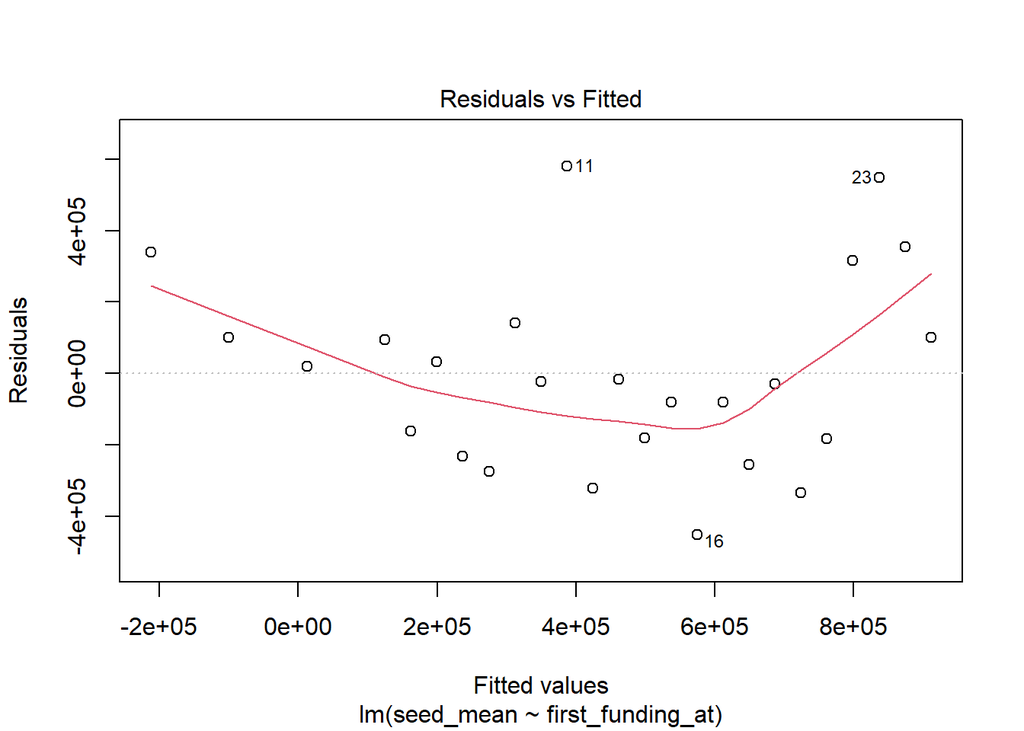

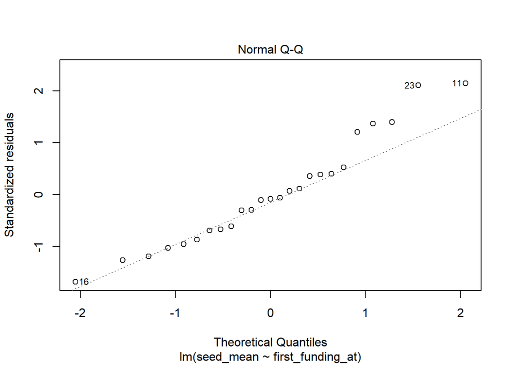

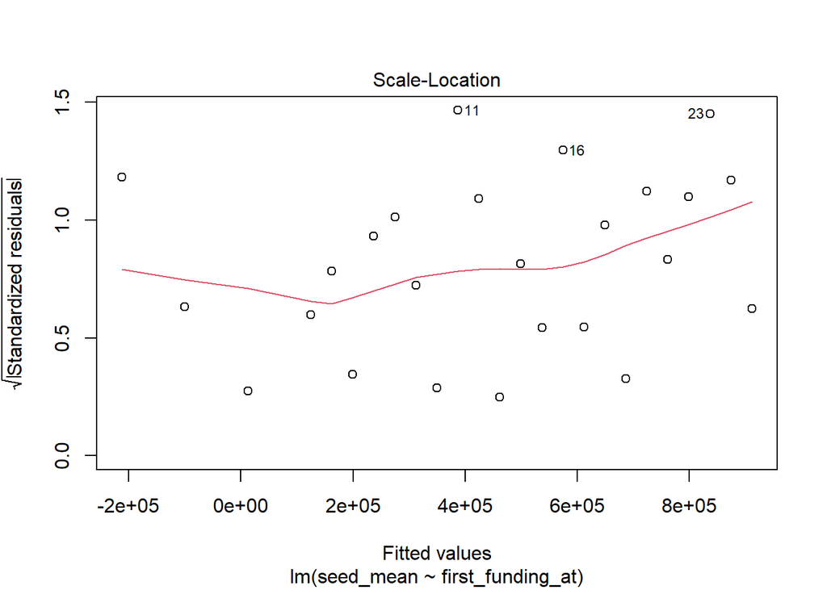

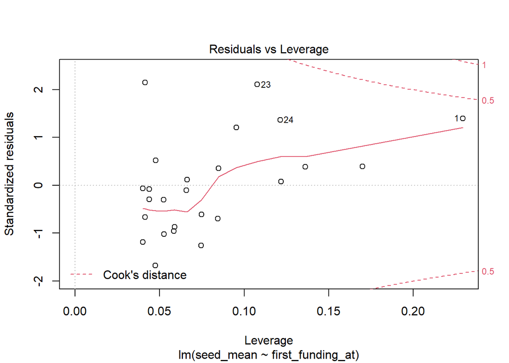

```r
plot(model)
```

It’s quite clear that the constant variance assumption for linear regression is not met which gives us enough reason to invalidate our linear model.

**We realized that when dealing with very large values like monies in company funding we can not capture the necessary relationship to model the data and make relative comparisons without making a transformation to the data.**

There are two way we can work with this data. 1. Use a log transform on the fields that include funding amounts and perform linear regression, or 2. Use Poisson regression to better describe this type of data.

## 1. Log transforms on the seed funding data and exploring seed funding chance.

### Can we seperate the chance of seed funding from the amount?

Let us transform our data taking the log(seed_funding) for the companies that received seed funding amounts.

```r
# Add the required new columns
decompData <- first_funding_date
decompData$seed <- decompData$inflationAdjustedSeed_1980
decompData$got_seed <- decompData$seed > 0
decompData$log_seed <- log(decompData$seed)
decompData[is.infinite(decompData$log_seed),]$log_seed <- -9999999999999
decompData_with_seed <- decompData[decompData$got_seed == TRUE,]
data.frame(decompData$first_funding_at, decompData$inflationAdjustedSeed_1980, decompData$log_seed, decompData$log_seed)
```

[output not shown]

[output cut: 37837 more lines]

Let us look at the transformed seed data over time.

```r
# Model seed chance
annualData <- do.call(data.frame, aggregate(cbind(seed, got_seed, log_seed)  ~ first_funding_at, data=decompData, FUN=mean))
model.seed_chance <- lm(formula = got_seed ~ first_funding_at, data = annualData[annualData$first_funding_at >= 1990,])
summary(model.seed_chance)
```

```
##
## Call:
## lm(formula = got_seed ~ first_funding_at, data = annualData[annualData$first_funding_at >=
##     1990, ])
##
## Residuals:
##      Min       1Q   Median       3Q      Max
## -0.23597 -0.12817 -0.03472  0.07866  0.76902
##
## Coefficients:
##                   Estimate Std. Error t value Pr(>|t|)
## (Intercept)      -2.255379  13.457608  -0.168    0.869
## first_funding_at  0.001248   0.006719   0.186    0.854
##
## Residual standard error: 0.2187 on 21 degrees of freedom
## Multiple R-squared:  0.001639,   Adjusted R-squared:  -0.0459
## F-statistic: 0.03448 on 1 and 21 DF,  p-value: 0.8545
```

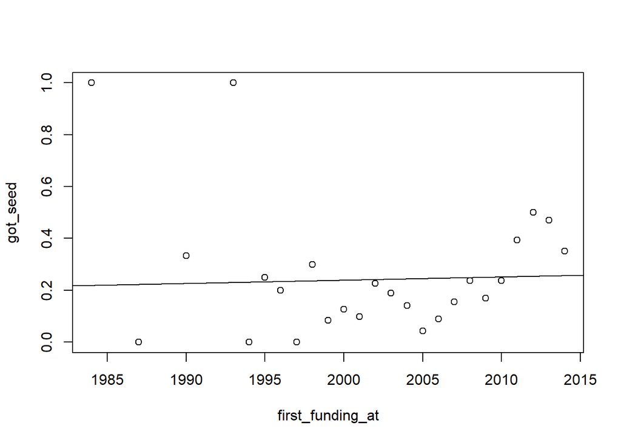

```r
plot(got_seed ~ first_funding_at, data=annualData); abline(model.seed_chance)
```

However, the inflation-adjusted amount of seed money raised increases over time with an average of $105.5(thousand) a year, at the 0.05 significance level.

```r
# Model seed amount
annualData.with_seed <- do.call(data.frame, aggregate(cbind(seed, got_seed, log_seed)  ~ first_funding_at, data=decompData_with_seed, FUN=mean))
model.seed_amount <- lm(formula = seed ~ first_funding_at, data = annualData.with_seed)
summary(model.seed_amount)
```

```
##
## Call:
## lm(formula = seed ~ first_funding_at, data = annualData.with_seed)
##
## Residuals:
##      Min       1Q   Median       3Q      Max
## -1641635  -731478  -500531  -179886  5540909
##
## Coefficients:
##                    Estimate Std. Error t value Pr(>|t|)
## (Intercept)      -209015538   92374693  -2.263   0.0349 *
## first_funding_at     105552      46124   2.288   0.0331 *
## ---
## Signif. codes:  0 '***' 0.001 '**' 0.01 '*' 0.05 '.' 0.1 ' ' 1
##
## Residual standard error: 1665000 on 20 degrees of freedom
## Multiple R-squared:  0.2075, Adjusted R-squared:  0.1679
## F-statistic: 5.237 on 1 and 20 DF,  p-value: 0.03313
```

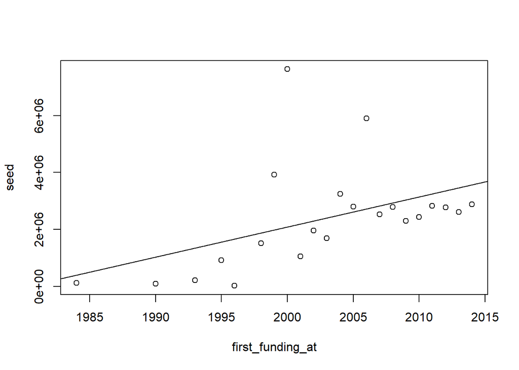

```r
plot(seed ~ first_funding_at, data=annualData.with_seed); abline(model.seed_amount)
```

*The residuals deviate significantly from normal on the high end, so this model may not be valid. (As shown below.)*

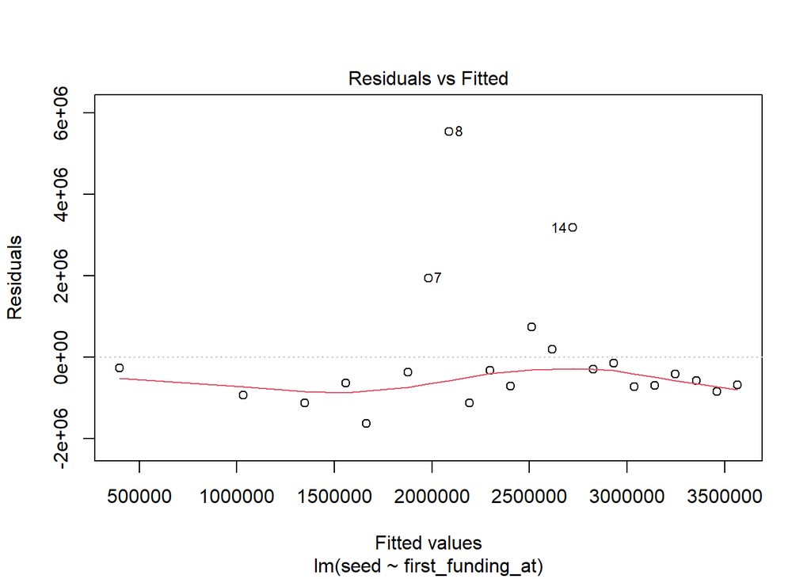

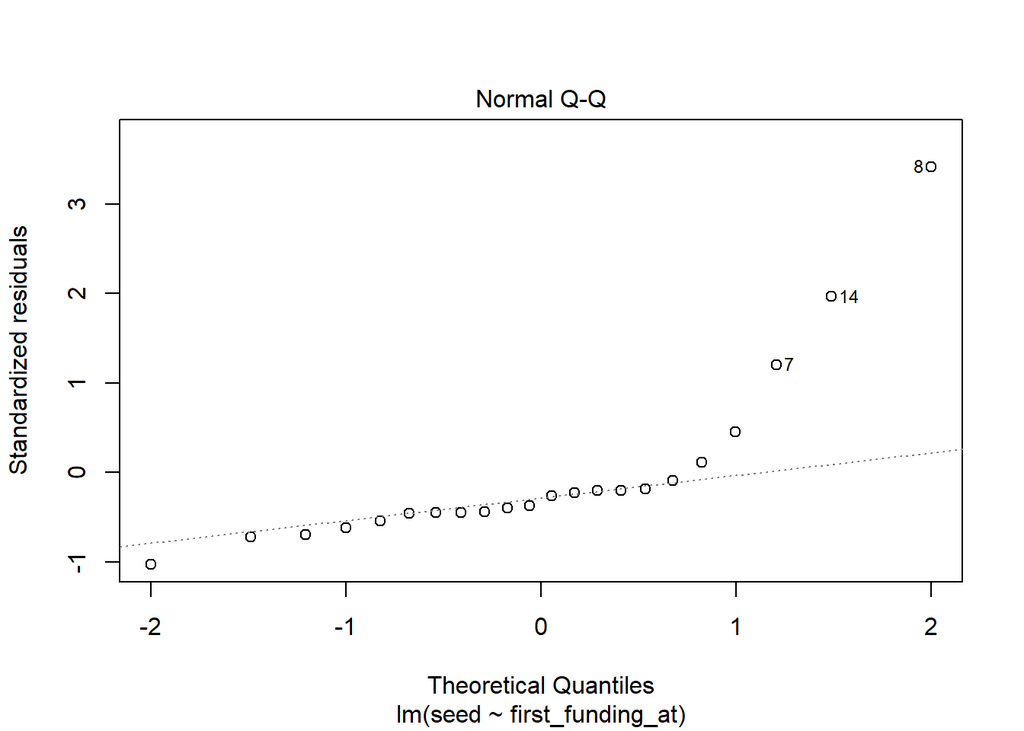

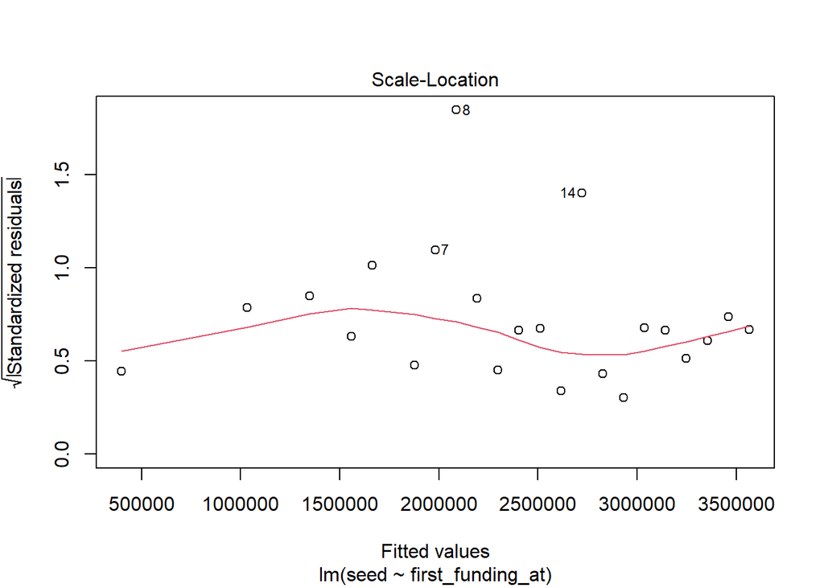

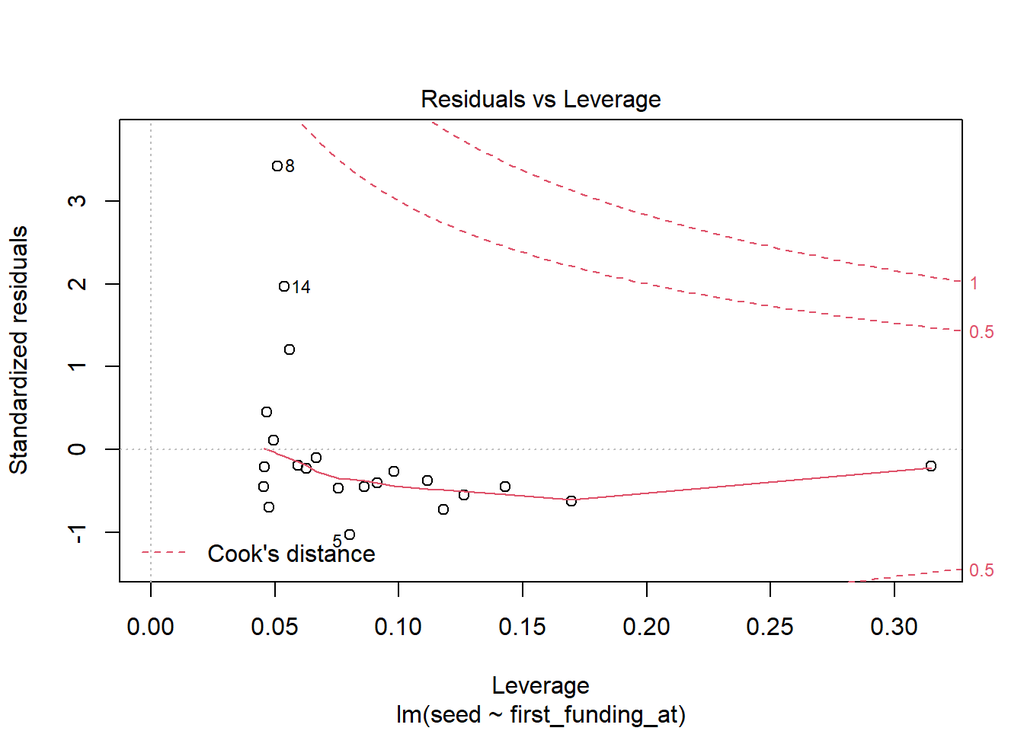

```r
plot(model.seed_amount)
```

Here we also see a case of Simpsons Paradox, where grouping the data reverses the apparent trend. If we look at all non-zero data points, not grouped by year, we get a negative relationship, as shown below.

```r
# Model seed amount
model.seed_amount_ungrouped <- lm(formula = seed ~ first_funding_at, data = decompData_with_seed)
summary(model.seed_amount_ungrouped)
```

```
##
## Call:
## lm(formula = seed ~ first_funding_at, data = decompData_with_seed)
##
## Residuals:
##       Min        1Q    Median        3Q       Max
##  -3312538  -2368659  -1203993   1098202 242121793
##
## Coefficients:
##                  Estimate Std. Error t value Pr(>|t|)
## (Intercept)      53970262   58253244   0.926    0.354
## first_funding_at   -25470      28961  -0.879    0.379
##
## Residual standard error: 5064000 on 5994 degrees of freedom
## Multiple R-squared:  0.000129,   Adjusted R-squared:  -3.779e-05
## F-statistic: 0.7734 on 1 and 5994 DF,  p-value: 0.3792
```

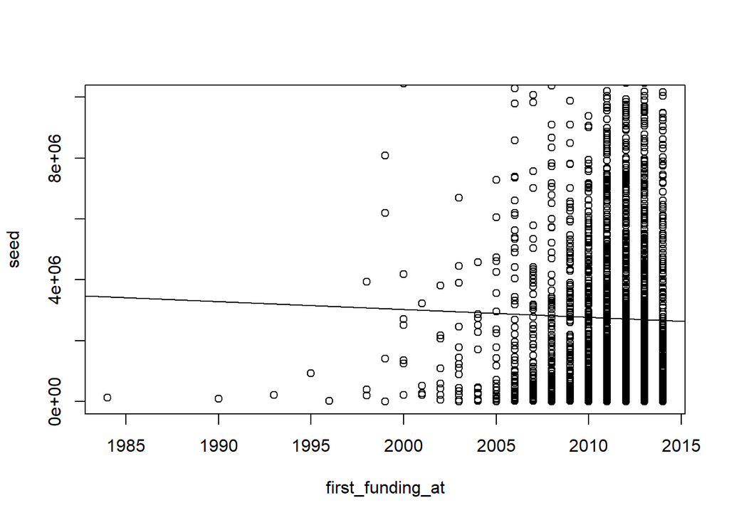

```r
plot(seed ~ first_funding_at, data=decompData_with_seed, ylim=c(0, 10000000)); abline(model.seed_amount_ungrouped)
```

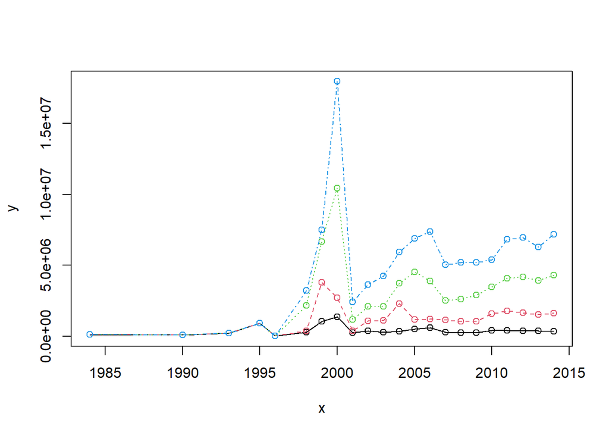

```r
library(e1071)
annualData.quants <- do.call(data.frame, aggregate(seed  ~ first_funding_at, data=decompData_with_seed, FUN=function(x){quantile(x, probs=c(0.25, 0.5, 0.75, 0.9))}))
x <- cbind(annualData.quants$first_funding_at, annualData.quants$first_funding_at, annualData.quants$first_funding_at, annualData.quants$first_funding_at)
y <- cbind(annualData.quants$seed.25., annualData.quants$seed.50., annualData.quants$seed.75., annualData.quants$seed.90. )
matplot(x, y, type="o", pch=1)
```

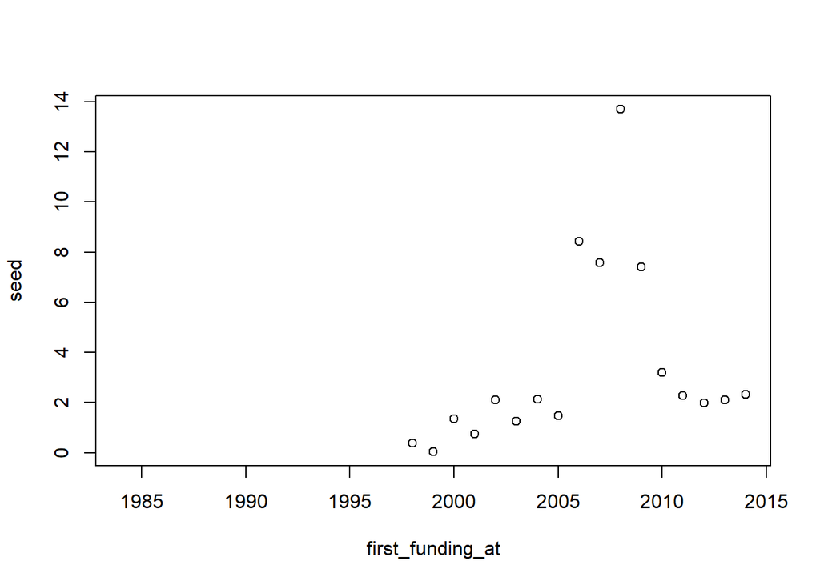

```r
annualData.skew <- do.call(data.frame, aggregate(seed  ~ first_funding_at, data=decompData_with_seed, FUN=skewness))
plot(seed ~ first_funding_at, data=annualData.skew)
```

Linear tests confirm, there is not evidence to reject that the 25th quantile is constant over time, while there is enough to reject that the 90th quantile is constant at the 0.05 significance level.

```r
model.25q <- lm(seed.25. ~ first_funding_at, data=annualData.quants)
summary(model.25q)
```

```
##
## Call:
## lm(formula = seed.25. ~ first_funding_at, data = annualData.quants)
##
## Residuals:
##     Min      1Q  Median      3Q     Max
## -381042 -165306  -83646  -28120  945605
##
## Coefficients:
##                  Estimate Std. Error t value Pr(>|t|)
## (Intercept)      -3638513   18088242  -0.201    0.843
## first_funding_at     2026       9032   0.224    0.825
##
## Residual standard error: 325900 on 20 degrees of freedom
## Multiple R-squared:  0.002509,   Adjusted R-squared:  -0.04737
## F-statistic: 0.0503 on 1 and 20 DF,  p-value: 0.8248
```

```r
model.90q <- lm(seed.90. ~ first_funding_at, data=annualData.quants)
summary(model.90q)
```

```
##
## Call:
## lm(formula = seed.90. ~ first_funding_at, data = annualData.quants)
##
## Residuals:
##      Min       1Q   Median       3Q      Max
## -3246909 -1334371  -872786  -162877 13707506
##
## Coefficients:
##                    Estimate Std. Error t value Pr(>|t|)
## (Intercept)      -493650679  193162260  -2.556   0.0188 *
## first_funding_at     248959      96449   2.581   0.0178 *
## ---
## Signif. codes:  0 '***' 0.001 '**' 0.01 '*' 0.05 '.' 0.1 ' ' 1
##
## Residual standard error: 3481000 on 20 degrees of freedom
## Multiple R-squared:  0.2499, Adjusted R-squared:  0.2124
## F-statistic: 6.663 on 1 and 20 DF,  p-value: 0.01784
```

Looking at the inflation-adjusted log of seed money makes the trend more clear, with seed funding growing at about 9% per year at the 0.01 significance level.

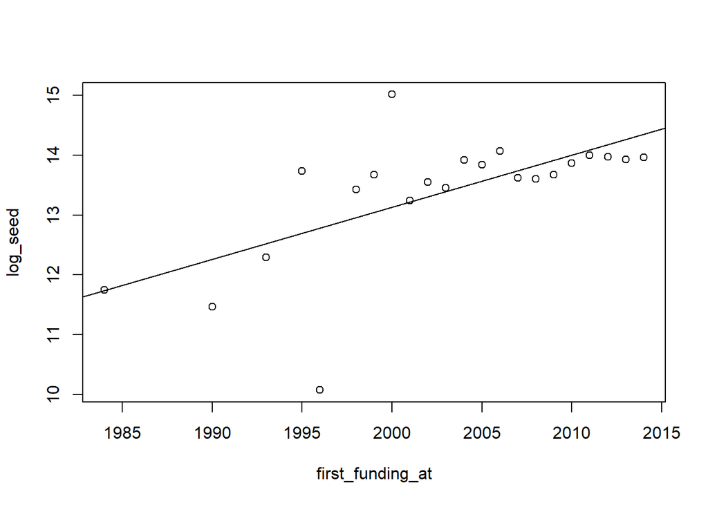

```r
# Model log seed amount
model.seed_amount_log <- lm(formula = log_seed ~ first_funding_at, data = annualData.with_seed, na.action=na.omit)
plot(log_seed ~ first_funding_at, data=annualData.with_seed); abline(model.seed_amount_log)
```

```r
print(summary(model.seed_amount_log))
```

```
##
## Call:
## lm(formula = log_seed ~ first_funding_at, data = annualData.with_seed,
##     na.action = na.omit)
##
## Residuals:
##      Min       1Q   Median       3Q      Max
## -2.70655 -0.22654 -0.04371  0.37805  1.88341
##
## Coefficients:
##                    Estimate Std. Error t value Pr(>|t|)
## (Intercept)      -161.50208   46.79713  -3.451  0.00253 **
## first_funding_at    0.08732    0.02337   3.737  0.00130 **
## ---
## Signif. codes:  0 '***' 0.001 '**' 0.01 '*' 0.05 '.' 0.1 ' ' 1
##
## Residual standard error: 0.8433 on 20 degrees of freedom
## Multiple R-squared:  0.4111, Adjusted R-squared:  0.3817
## F-statistic: 13.96 on 1 and 20 DF,  p-value: 0.001301
```

## 2. Use Poisson regression to better describe this type of data.

Let us try Poisson regression *without* averaging by year.

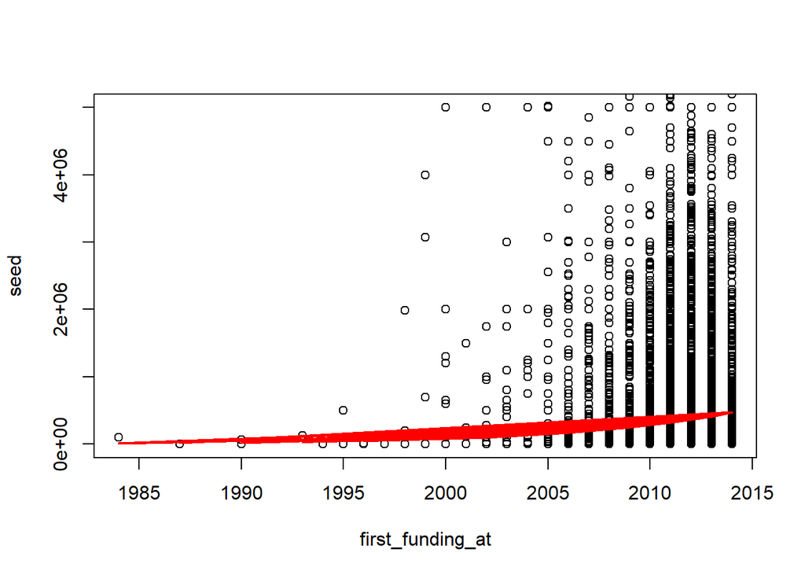

```r
# Model poisson seed
model.seed_amount_pois <- glm(formula = seed ~ first_funding_at, data = first_funding_date, family=poisson, na.action=na.omit)
plot(seed ~ first_funding_at, data=first_funding_date, ylim=c(0,5000000))
points(first_funding_date$first_funding_at, exp(predict(model.seed_amount_pois)), type="l", col="red", lwd=2)
```

```r
print(summary(model.seed_amount_pois))
```

```
##
## Call:
## glm(formula = seed ~ first_funding_at, family = poisson, data = first_funding_date,
##     na.action = na.omit)
##
## Deviance Residuals:
##    Min      1Q  Median      3Q     Max
##   -971    -803    -707    -442   32784
##
## Coefficients:
##                    Estimate Std. Error z value Pr(>|z|)
## (Intercept)      -2.426e+02  1.072e-02  -22632   <2e-16 ***
## first_funding_at  1.270e-01  5.330e-06   23819   <2e-16 ***
## ---
## Signif. codes:  0 '***' 0.001 '**' 0.01 '*' 0.05 '.' 0.1 ' ' 1
##
## (Dispersion parameter for poisson family taken to be 1)
##
##     Null deviance: 2.1908e+10  on 18924  degrees of freedom
## Residual deviance: 2.1268e+10  on 18923  degrees of freedom
## AIC: 2.1268e+10
##
## Number of Fisher Scoring iterations: 8
```

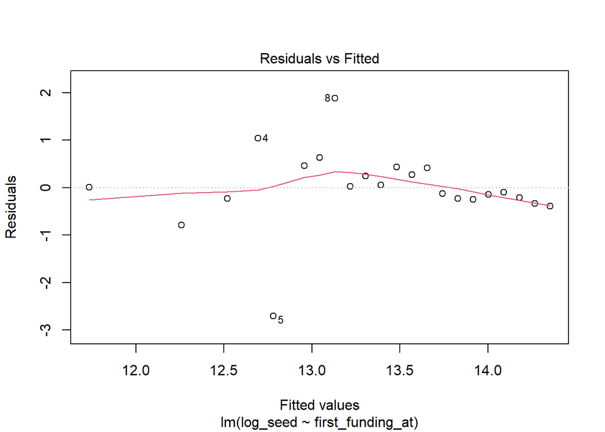

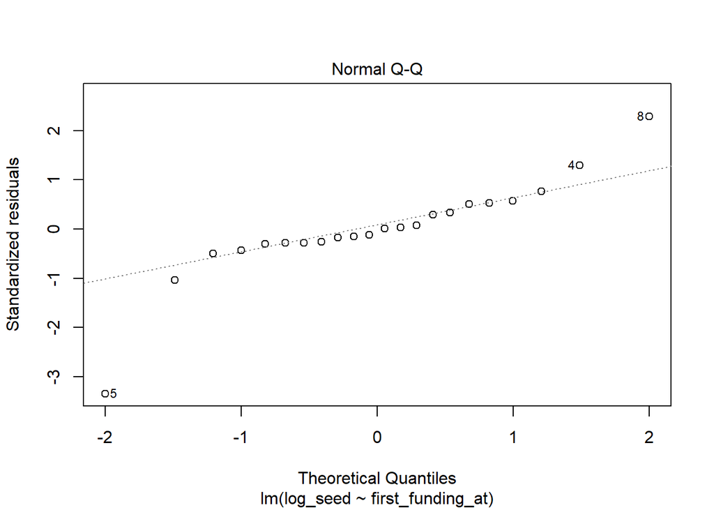

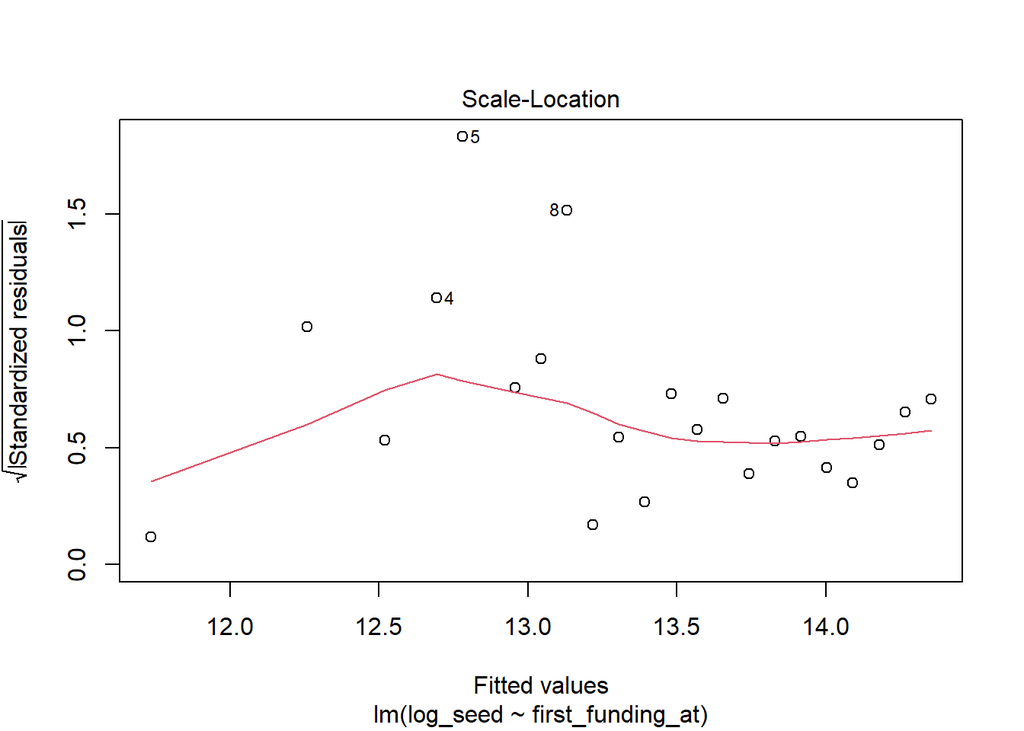

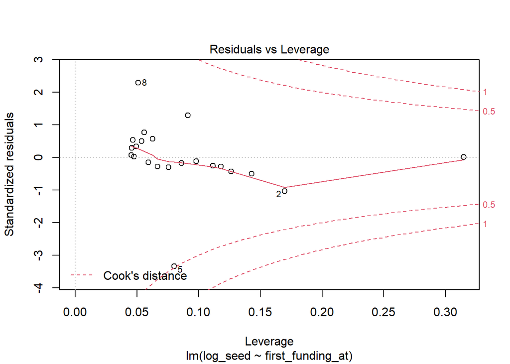

```r
plot(model.seed_amount_log)
```

Let us try Poisson regression *with* averaging by year.

```r
# Model poisson seed
mean_compare_pois <- first_funding_date %>%
    group_by(first_funding_at) %>%
    dplyr::summarize(seed_mean = mean(inflationAdjustedSeed_1980, na.rm=TRUE))
model.seed_amount_pois <- glm(formula = seed_mean ~ first_funding_at, data = mean_compare_pois, family=poisson, na.action=na.omit)
```

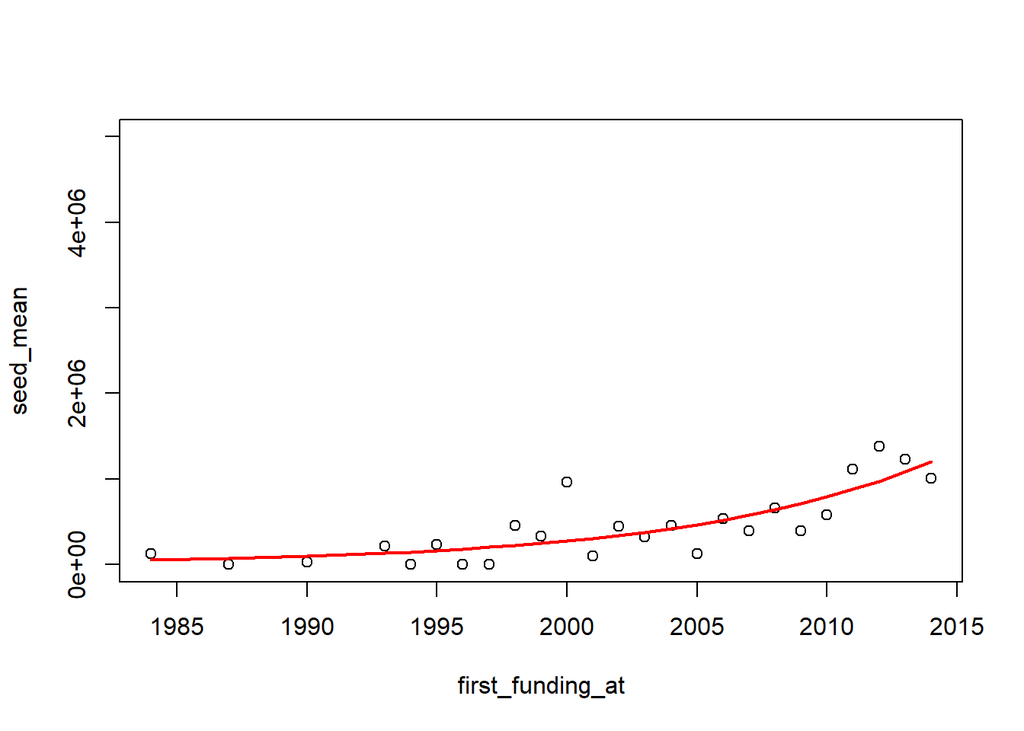

```r
plot(seed_mean ~ first_funding_at, data = mean_compare_pois, ylim=c(0,5000000))
points(mean_compare_pois$first_funding_at, exp(predict(model.seed_amount_pois)), type="l", col="red", lwd=2)
```

```r
print(summary(model.seed_amount_pois))
```

```
##
## Call:
## glm(formula = seed_mean ~ first_funding_at, family = poisson,
##     data = mean_compare_pois, na.action = na.omit)
##
## Deviance Residuals:
##     Min       1Q   Median       3Q      Max
## -636.21  -376.63    16.28   168.87  1018.26
##
## Coefficients:
##                    Estimate Std. Error z value Pr(>|z|)
## (Intercept)      -1.972e+02  9.707e-02   -2031   <2e-16 ***
## first_funding_at  1.049e-01  4.837e-05    2168   <2e-16 ***
## ---
## Signif. codes:  0 '***' 0.001 '**' 0.01 '*' 0.05 '.' 0.1 ' ' 1
##
## (Dispersion parameter for poisson family taken to be 1)
##
##     Null deviance: 9580985  on 24  degrees of freedom
## Residual deviance: 3759078  on 23  degrees of freedom
## AIC: Inf
##
## Number of Fisher Scoring iterations: 5
```

### THE FOLLOWING CAN BE DELETED. We are not using polynomial regression to stay within the scope of this class.

```
#POLYNOMIAL REGRESSION
#https://stats.stackexchange.com/questions/258307/raw-or-orthogonal-polynomial-regression for discussion on orthogonal polynomials.
p2model <- lm(seed_mean ~ poly(first_funding_at, 2), data = mean_compare) #poly(first_funding_at, 2, raw=TRUE)
p3model <- lm(seed_mean ~ poly(first_funding_at, 3), data = mean_compare)

summary(p2model)
summary(p3model)

print(anova(p2model, p3model))

plot(seed_mean ~ first_funding_at, data=mean_compare)
points(mean_compare$first_funding_at, predict(p2model), type="l", col="red", lwd=2)
points(mean_compare$first_funding_at, predict(p3model), type="l", col="blue", lwd=2)
```